# Storyboard

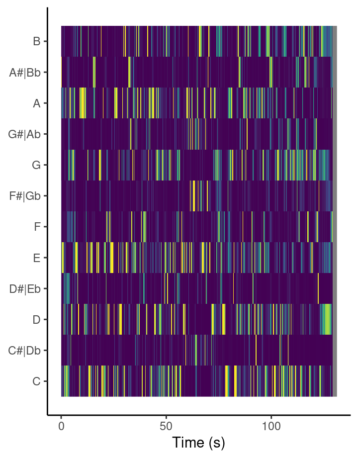

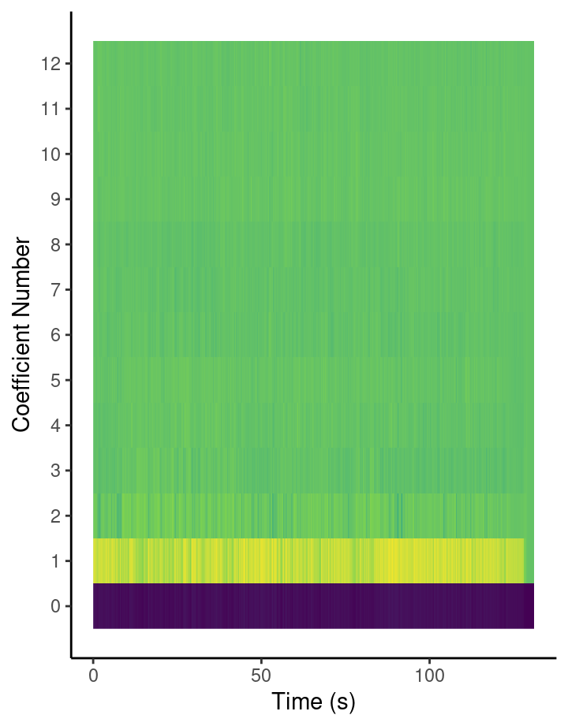

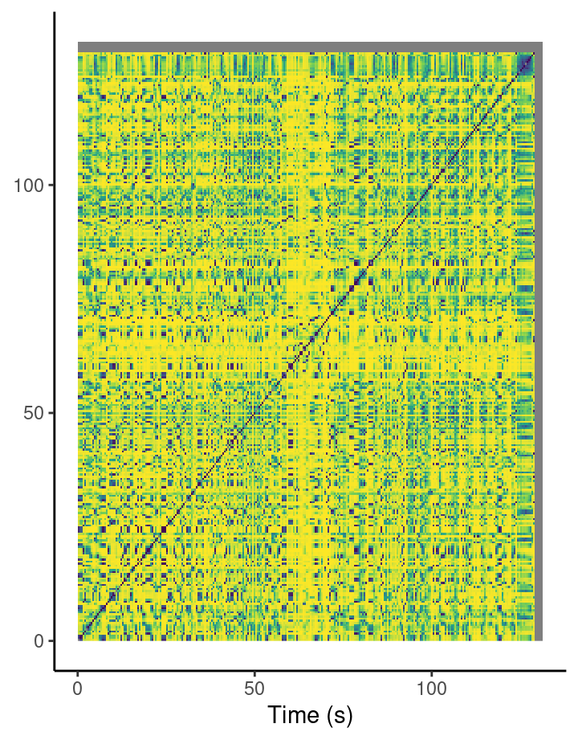

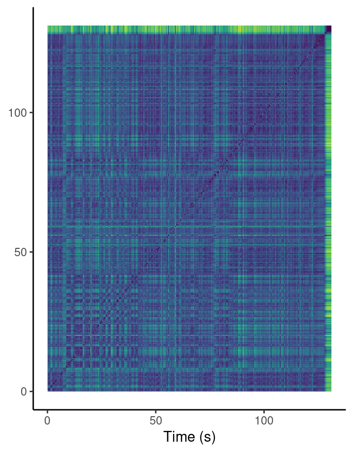

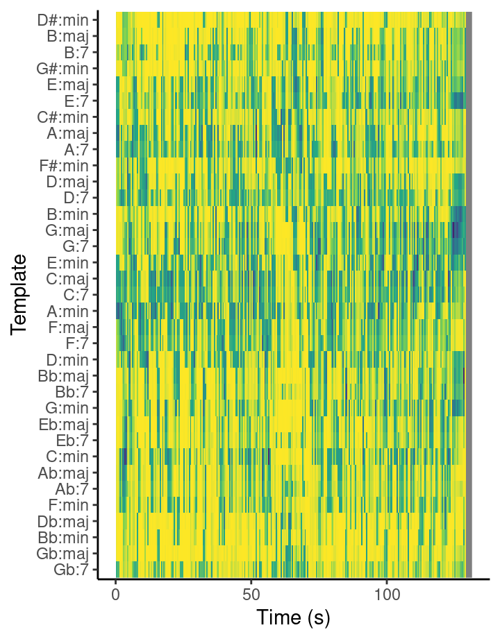

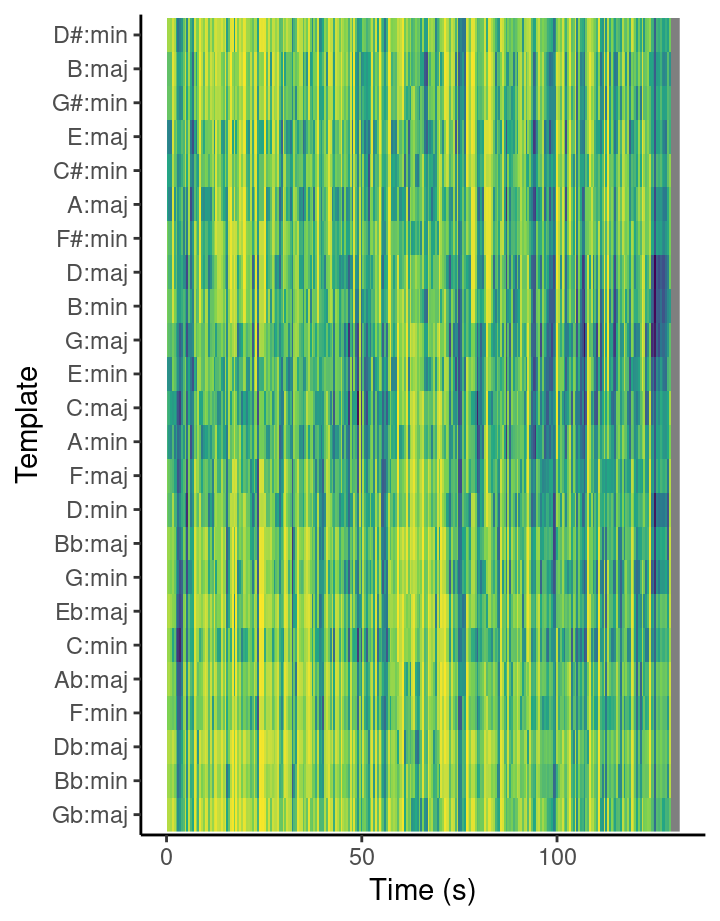

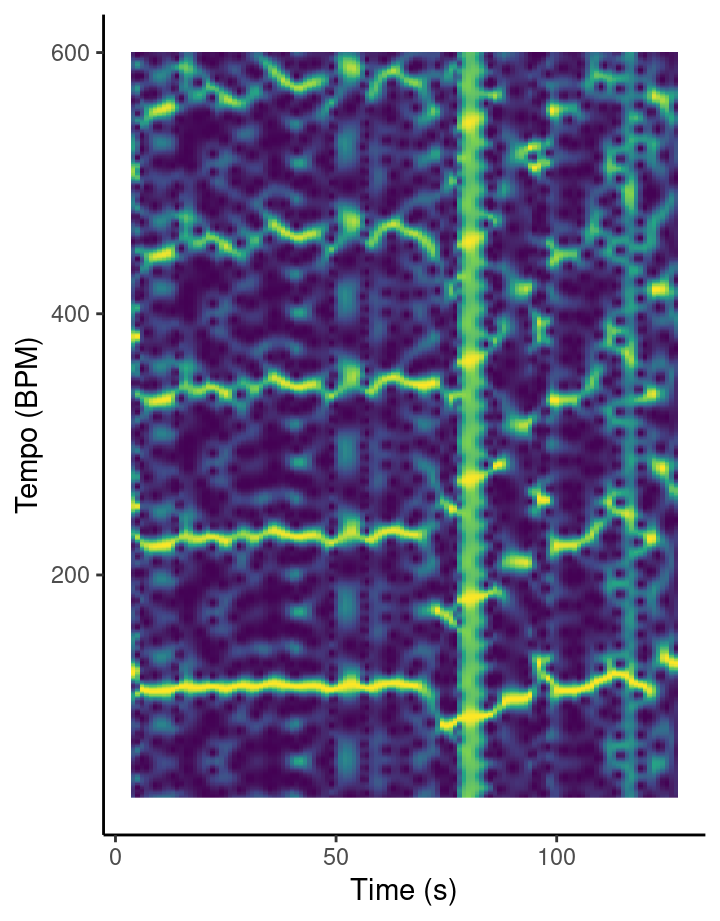

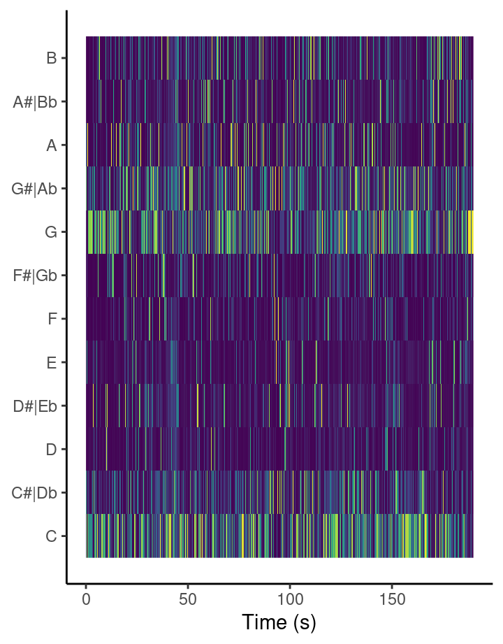

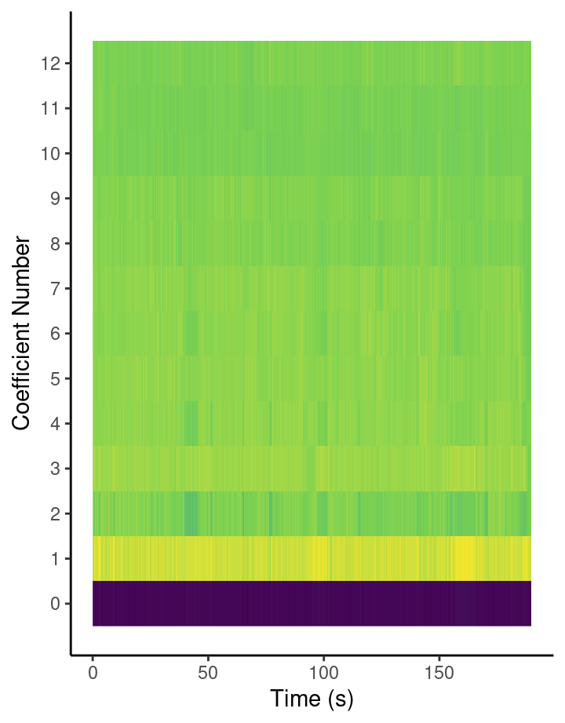

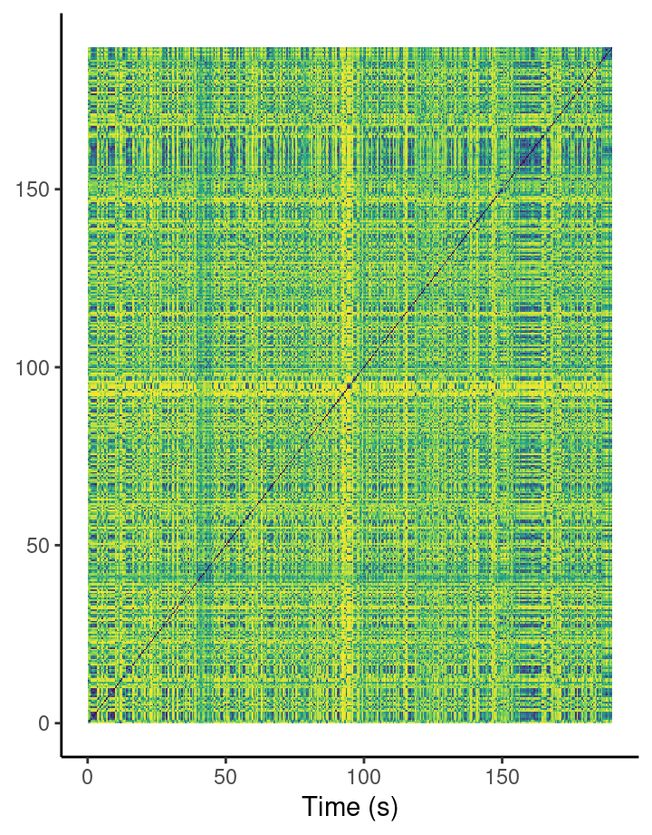

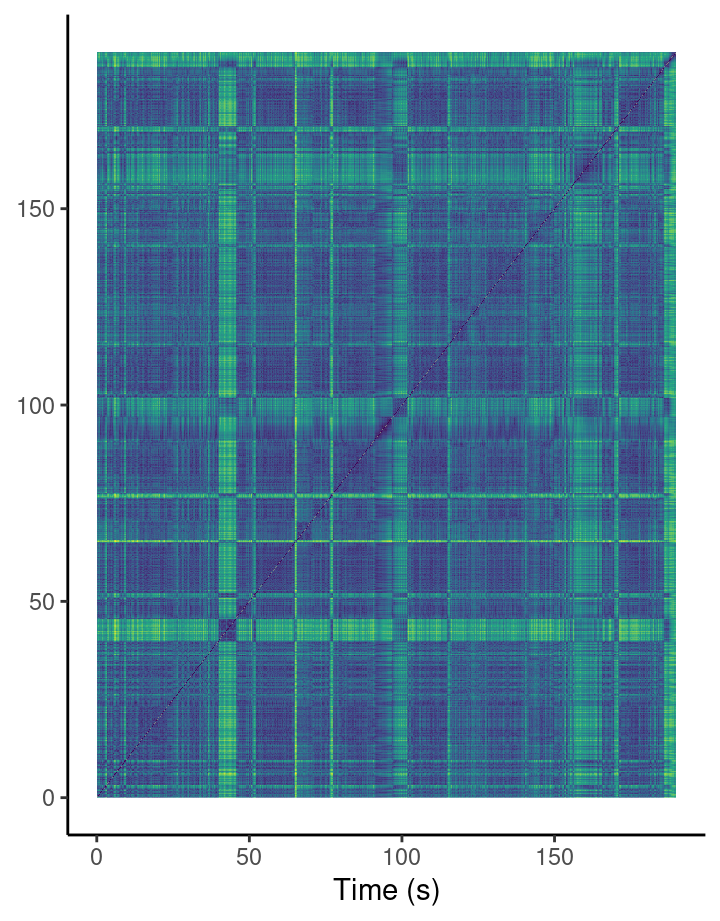

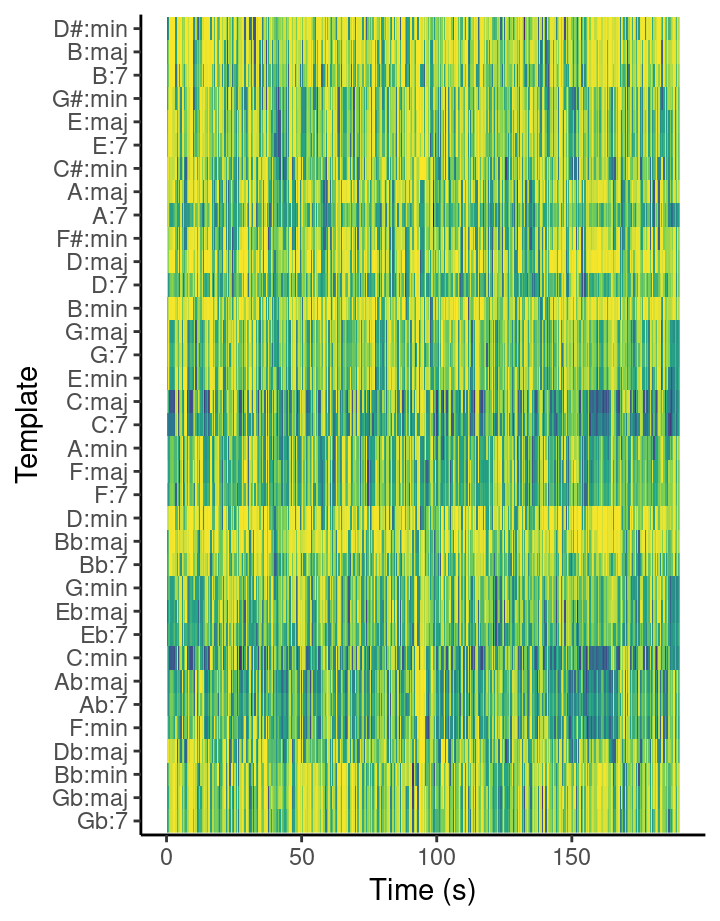

[12 more figures not shown]

# Introduction

#### **Tools**

In this portfolio we will be using a student musical corpus consisting of tracks submitted by students of the course Computational Musicology.  
Every student including myself has submitted two tracks two the corpus.  
We have also been given access to high-level and low level features datasets.

#### **Track Selection**

For the creation of the two tracks i used the generative AI tools Udio and Suno.  
I wanted to create two tracks from two substantially different genres which contain a variety of different instruments.  
The genres i ended up choosing were jazz and metal.  
I decided not to generate any music with vocals as they always sound a bit off.  
I am very happy with the results of both tracks and hope the difference in instruments can help me gain more insight into music features like timbre.

- **Using Udio, prompts for track 1 (Jazz track):**  
  jazz, brazz instruments, key of B flat, piano, jazz band, cello, guitar, drums, saxophone, piano solo, saxophone solo, drum solo,
- **Using Suno, prompts for track 2 (Metal track):**  
  electric doom metal, dark, e key, electric, metal, low, doom metal

#### **Goal**

The goal of this portfolio is to analyze the student musical corpus with the focus on the two tracks i have submitted.  
I will start of by creating multiple graphs for my two tracks to not only analyze each track individually but also compare them.  
Following this i will try to get a better understanding of feature patterns in the student musical corpus using correlation graphs and unsupervised learning.  
This should also give us a better idea where my two tracks fit inside the pattern of the corpus.

# Track 1

### Chromagram Track 1

#### Analysis

Looking at the chromagram from track 1, we see that there isn’t a consistent pattern.  
A variety of different pitches seem to peak throughout the song.  
This could be related to the fact that jazz songs often have key changes.  
However we do see a lack of presence in the B flat pitch.  
This might point to a failure in the generative AI to follow the B flat prompt.

#### Chromagram

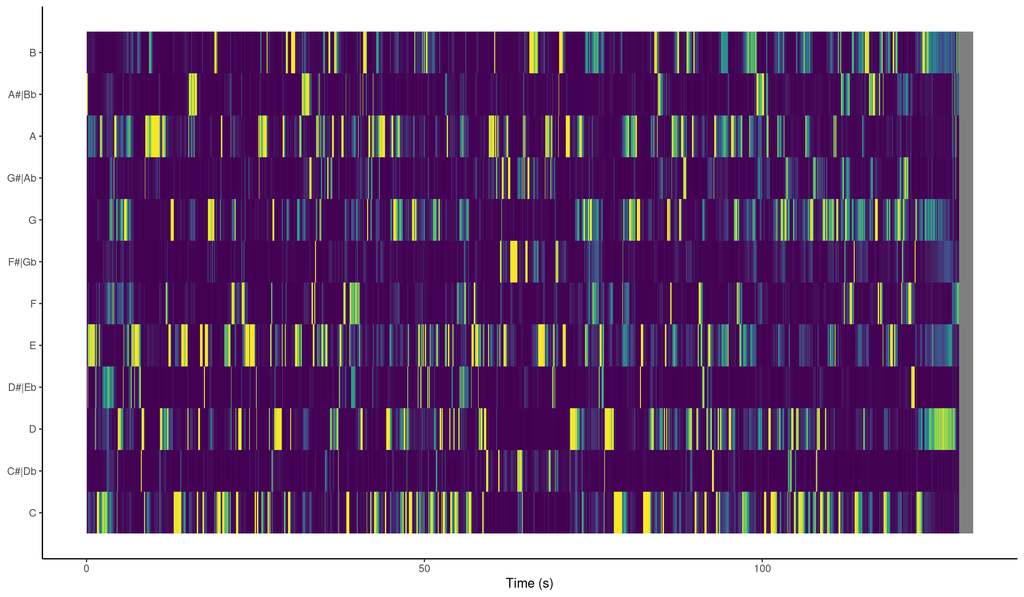

### Chroma-based self-similarity track 1

#### Analysis

From the chroma-based self-similarity chart we can see that there isn’t a coherent pattern or diagonal line which could display repeated sections.  
However there are a lot of bright areas indication a strong harmonic similarity throughout the song.  
Next to the brighter areas we often see these blocks of very dark regions which might imply a key change in the song.

#### Chroma-based self-similarity

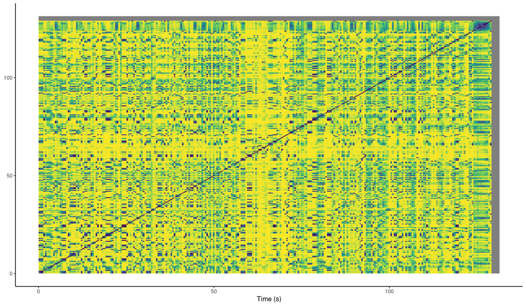

### Timbre-based self-similarity track 1

#### Analysis

Looking at the timbre-based self-similarity we don’t see any major changes in brightness.  
There is a faint pattern visible in the beginning of the song however this pattern fades as the song goes on.  
The faint pattern might imply that there is a greater timbre similarity in the first 50 seconds of the song.  
This could mean that during the first 50 second a certain set of instruments is repeatedly playing a certain riff or is playing an intro which has a consistent timbre.

#### Timbre-based self-similarity

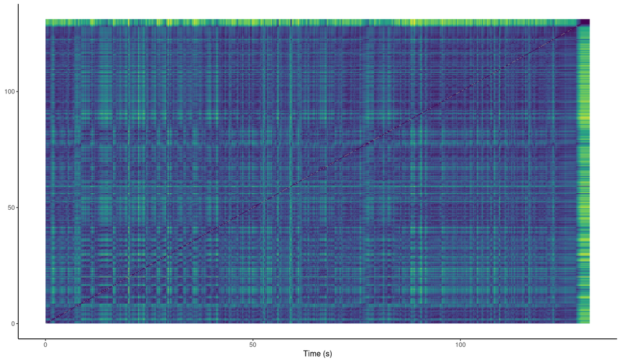

### Chordogram Track 1

#### Analysis

The chordogram does not display a clear chord structure.  
This does correlate with the lack of patterns in the chromagram.  
The chords seem to change often throughout the song which we can see from the chordogram not having a clear horizontal line.  
We do however see a lot more dark regions around the C major, C7, A minor, D7, A7, F7, D minor, C minor and F minor.  
The fact that there is a lot of presence in the dominant 7ths does correlate with the properties of Jazz.

#### Chordogram Track

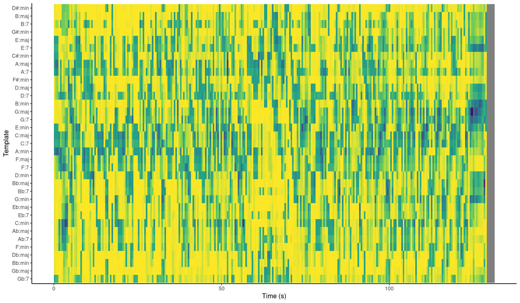

### Tempogram Track 1

#### Analysis

Looking at the tempogram of track 1 we can see that the tempo is not stable throughout the song.  
There is a big drop in tempo at the halfway mark of the song.  
After this drop the tempo starts increasing again.  
This abrupt tempo change is called rubato which is a musical term for playing with rhythmic freedom.  
Rubato is a common style in jazz music.

#### Tempogram Track

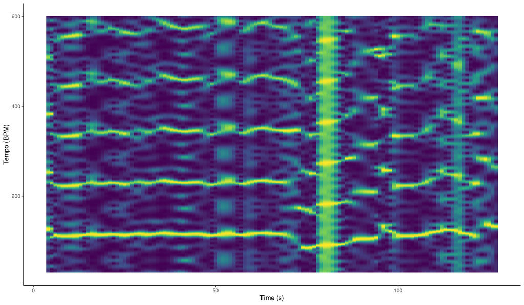

# Track 2

### Chromagram Track 2

#### Analysis

Looking at the chromagram from track 2, we see a strong presence in the pitch classes C, D flat, G, and A flat.  
This might point to it being in the key of c with the mode being phrygian.  
This would not be surprising as the phrygian mode is very popular in the metal genre because of it’s dark sound.  
However, i did have “e key” in my prompts which means the generative AI was not able to follow that particular prompt to set the key of the generated song.

#### Chromagram

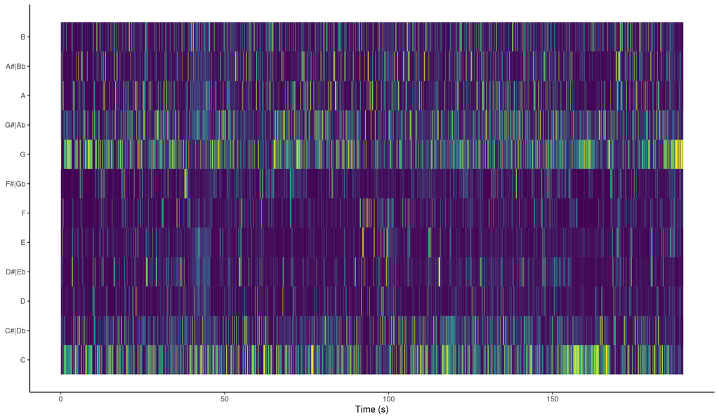

### Chroma-based self-similarity track 2

#### Analysis

Here we see a chroma-based self-similarity with a more noticable pattern which implies there is repetition.  
This makes sense as in metal you do often have a certain riff playing repeatedly and also a chorus. The bright areas are not as bright but the darker areas also seem to be not completely dark.  
There are however large dark regions which might be transitions between a verse and a chorus for example.

#### Chroma-based self-similarity

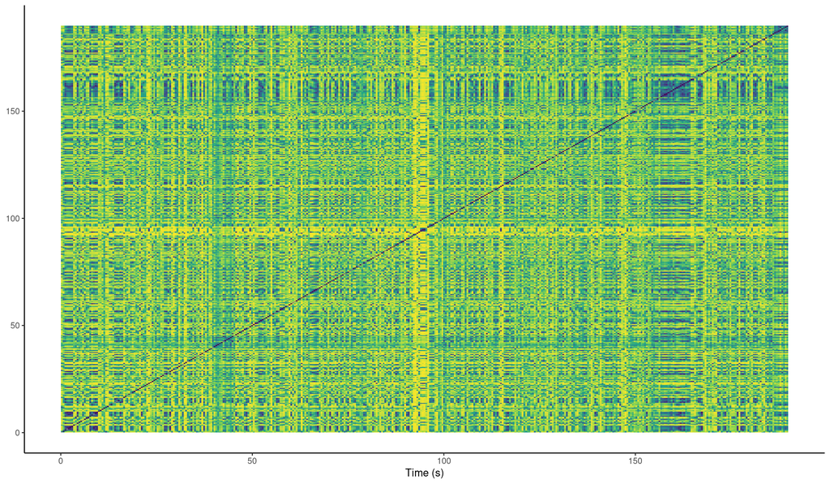

### Timbre-based self-similarity track 2

#### Analysis

From the Timbre-based self-similarity chart of track 2 we can see that there is a strong similarity at 3 intervals in the song.  
We can see this from the bright horizontal and vertical lines crossing the chart at these intervals.  
These lines most likely display the chorus of the song where all the instruments are playing the same part of the song the same way three times.  
This causes the timbre to be similar in these parts therefore showing up as a bright area in the chart.  
The rest of the song seems to be not have a lot of similarities in timbre excluding some small exceptions where there is a short bright line in the chart.

#### Timbre-based self-similarity

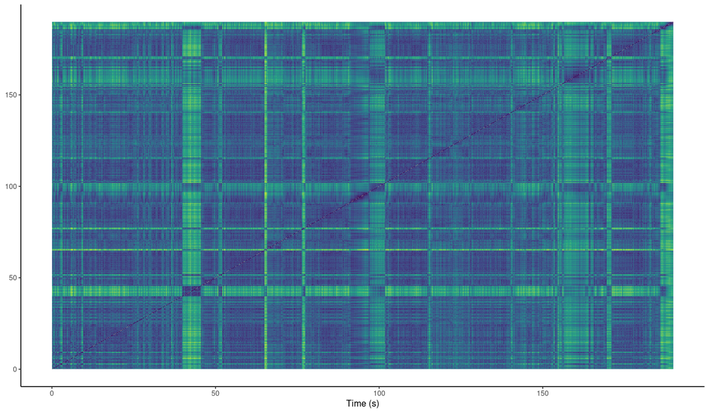

### Chordogram Track 2

#### Analysis

This chordogram shows clear presences at C major, C minor and C7 there are also dark areas at A7, D7, Ab minor, Ab7 and F minor but these are not as strong.  
From this we can conclude that track 2 is centered around C.  
This also seems to have a good amount of presence in dominant 7ths which might imply some jazz influence in the song.

#### Chordogram Track

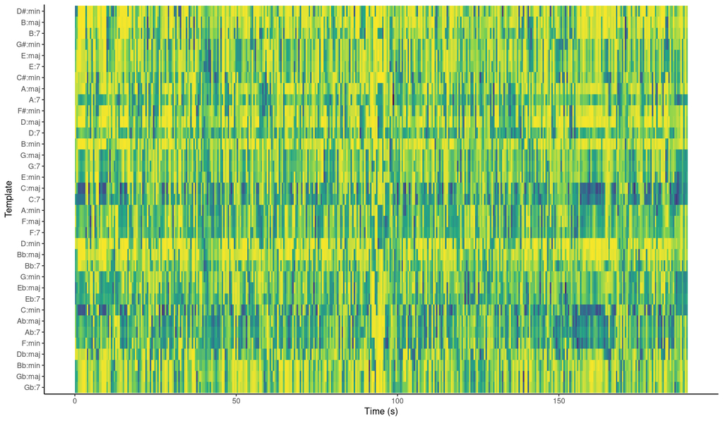

### Tempogram Track 2

#### Analysis

The tempogram shows a stable tempo in most of the song.  
There is a slight drop in tempo at the end of the song, after which the tempo returns to the stable tempo.  
This might be what is called a “breakdown” in the metal genre.  
A breakdown is where the tempo of the song “breaks” and every instrument start playing slower and darker.

#### Tempogram Track

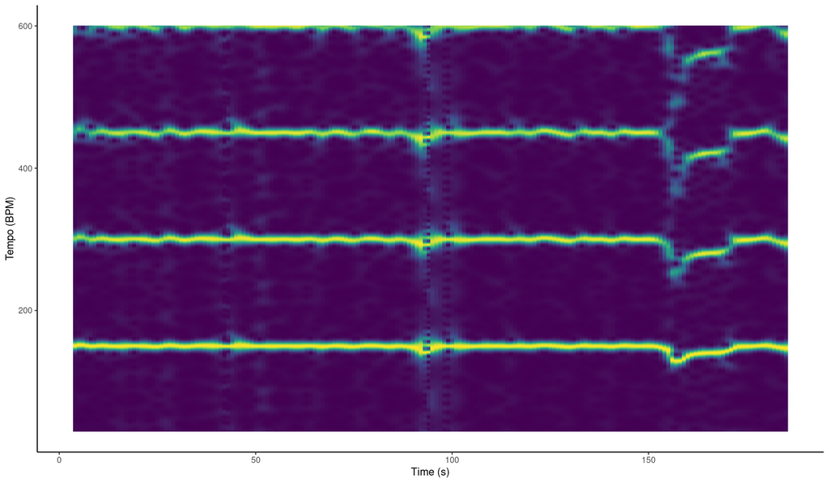

# Correlation

### Tempi Historgram

#### Analysis

Besides a peak at a tempo of around 150 bpm we can see that the songs in the student musical corpus are pretty evenly distributed between 50 and 160 bpm.  
Therefore i will be using compare other high-level features with the tempo’s of the songs to see if there is any correlation.  
I will be highlighting the my jazz track (track 1) with blue and my metal track (track 2) with red in further visualizations.

#### Tempi Histogram

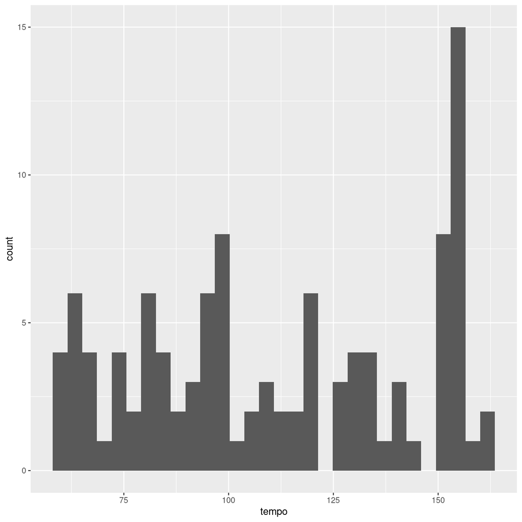

### Arousal

#### Arousal x Tempo

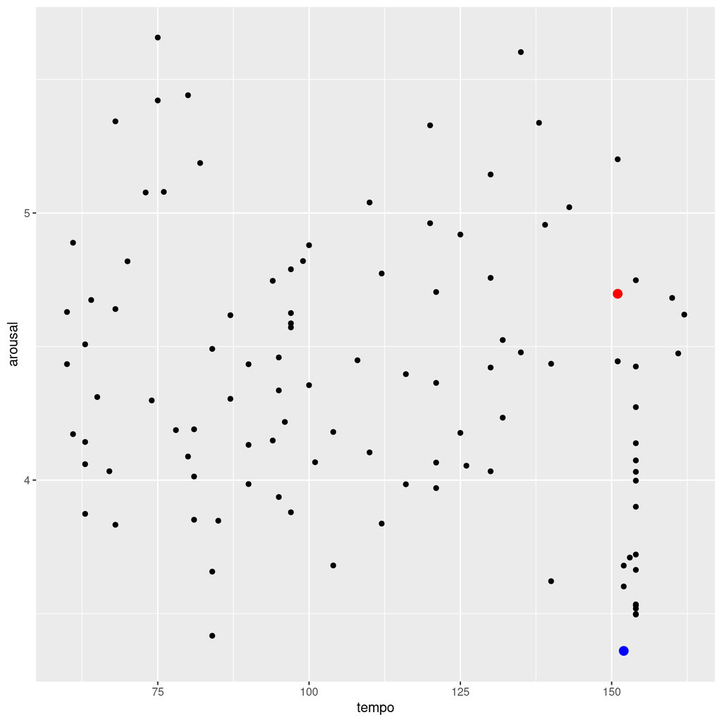

### Danceability

#### Analysis

There does not seem to be a correlation between tempo and danceability

#### Danceability x Tempo

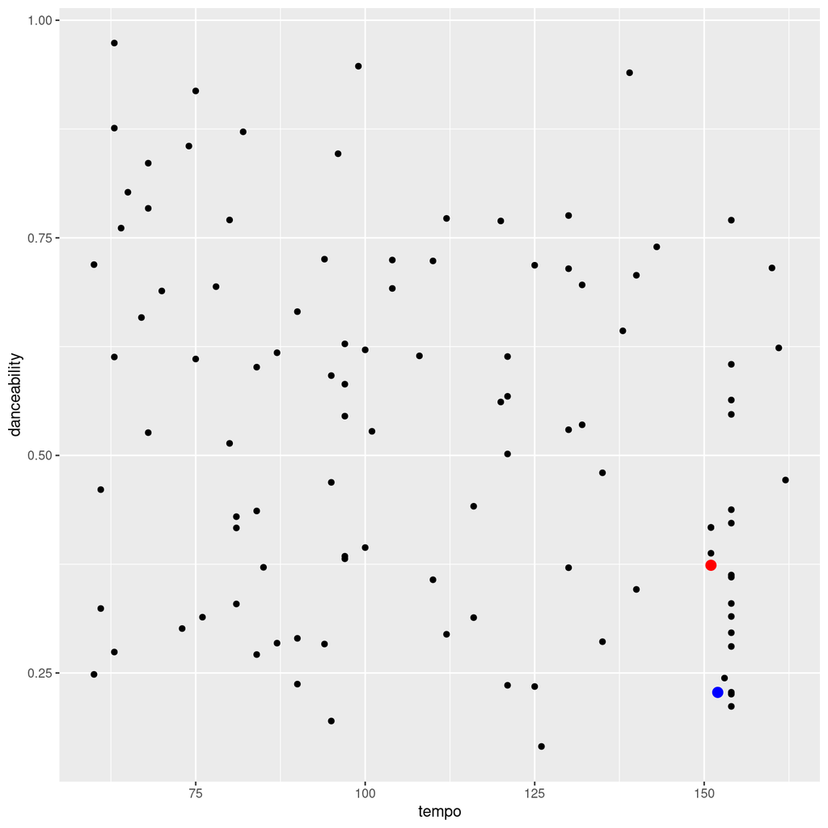

### Engagingness

#### Analysis

Engagingness seems to be slightly higher in lower tempo songs.

#### Engagingness x Tempo

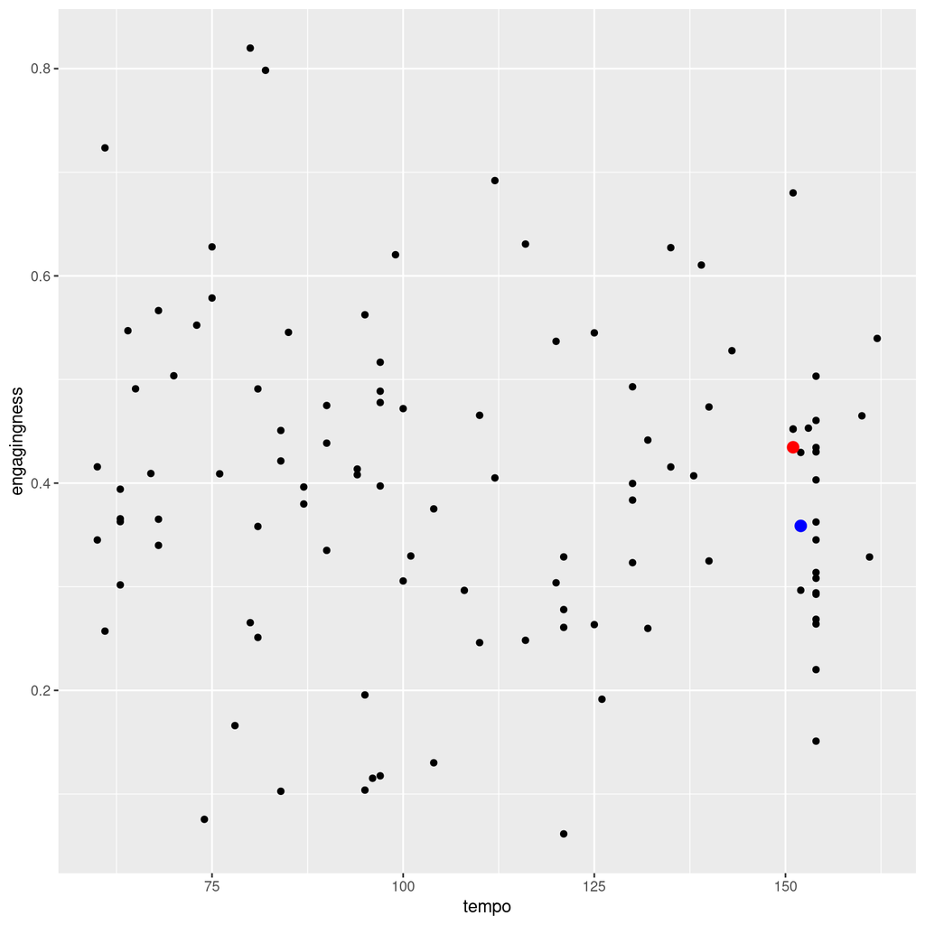

### Instrumentalness

#### Analysis

There seems to be an increase in Instrumentalness in higher tempo songs.

#### Instrumentalness x Tempo

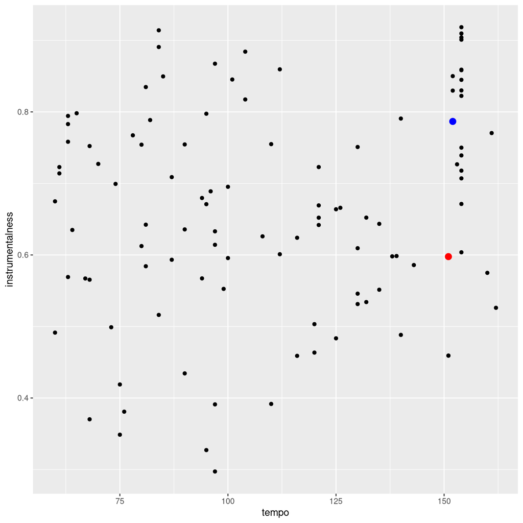

### Valence

#### Analysis

There seems to be a slight decrease in valence in higher tempo songs.

#### Valence x Tempo

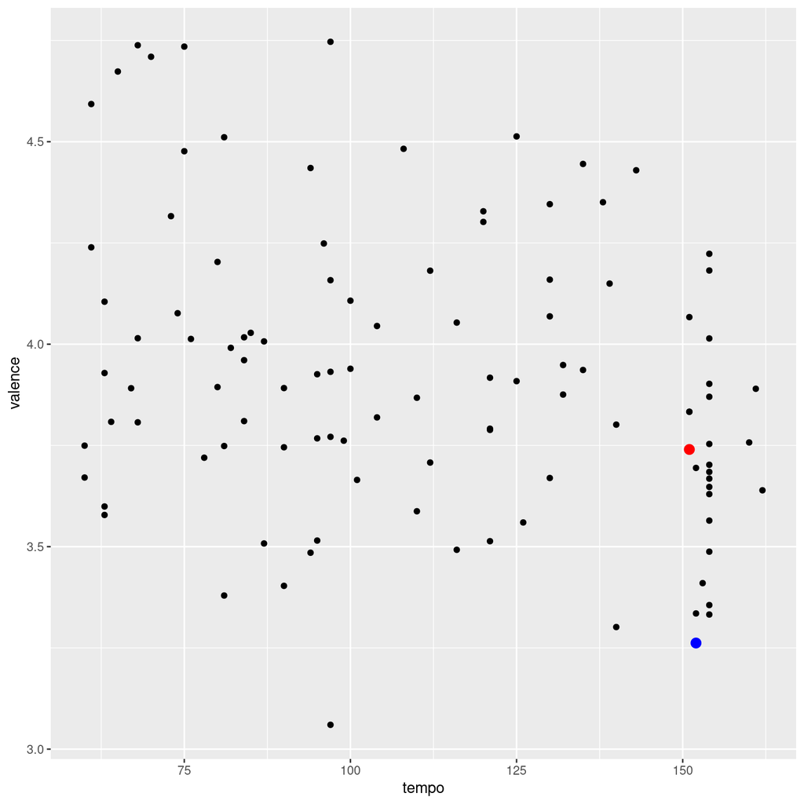

### Approachability

#### Approachability x Tempo

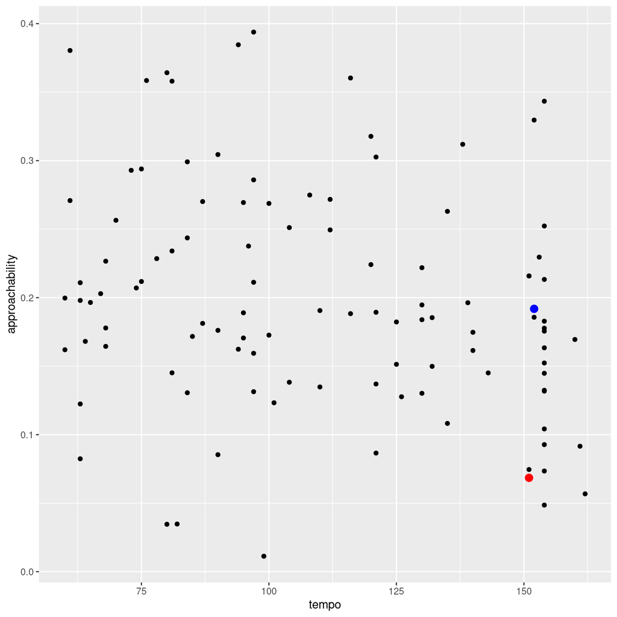

### Arousal x Engagingness

#### Analysis

According to this chart arousal and engagingness have a positive correlation.

#### Arousal x Engagingness chart

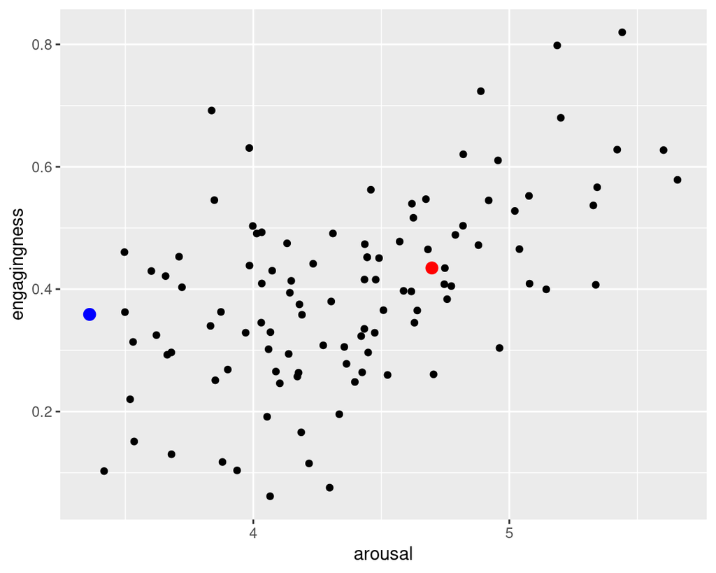

### Arousal x Instrumentalness

#### Analysis

According to this chart arousal and instrumentalness have a negative correlation.

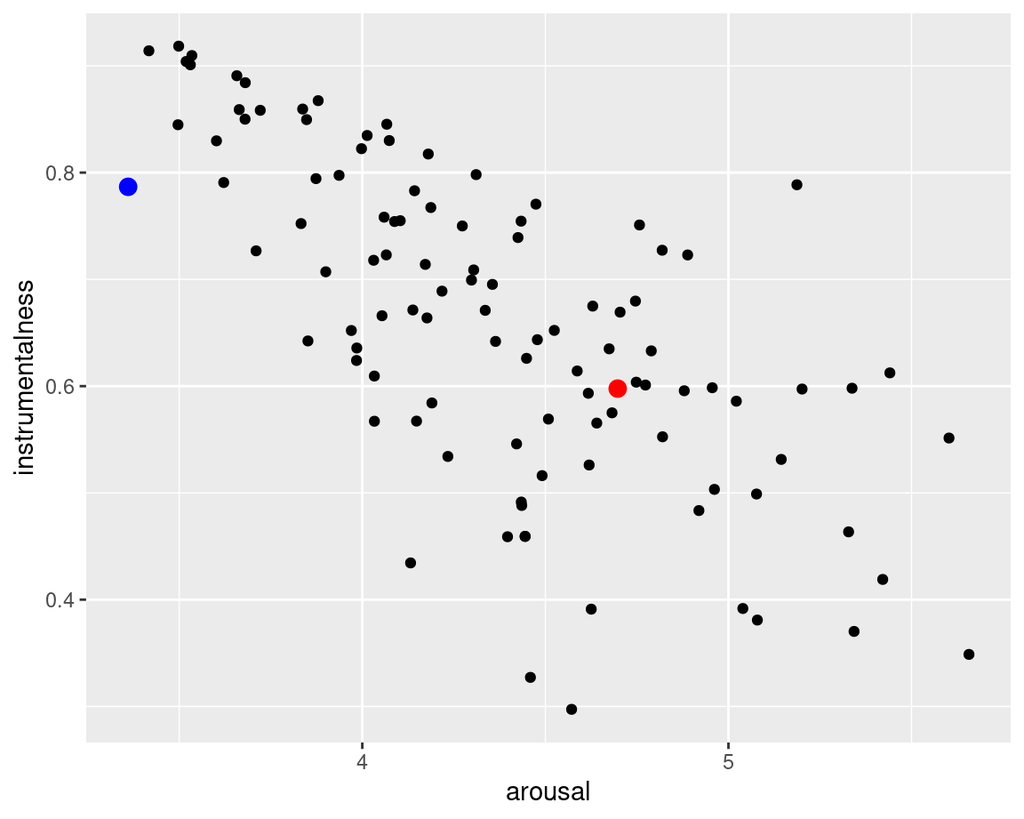

### Arousal x Danceability

According to this chart arousal and danceability have a positive correlation.

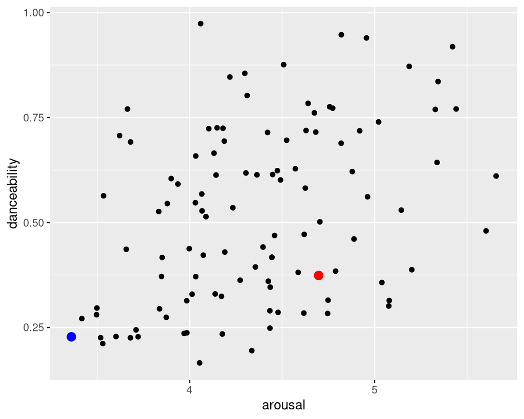

# Conclusion

### Conclusion

From the visualizations in this portfolio we can see that even though the song is AI generated it still has a lot of features that are present in that genre, this counts for both the jazz and the metal song.  
From this we can conclude that AI generation is pretty accurate at creating things like breakdown in a metal song or rubato in a jazz song.  
However, when generating the songs i made sure to include prompts for the key of the song but both models were not able to recreate this.  
The graphs i used to analyze my two track showed that jazz and metal don’t have that many overlapping musical features.